# How do acoustic features of songs influence their rank?

Authors: Yashas Lokesh, Renee Yang, Kavya Dagli

Musicologist Dr. Alison Pawley and psychologist Dr. Daniel Mullensiefen out at the University of London claim that it is possible to identify if a song will be popular. Two of the attributes that they predict make songs popular are "longer and detailed musical phrases" and "a higher number of pitches." We will put this claim to the test by analyzing the relationship between song audio features and song rank. We will also explore if there are additional features that influence popularity.

[figure not shown]

# 1. Getting Started

## 1.1 Required Libraries

```python
import warnings
warnings.filterwarnings("ignore")

import pandas as pd
import sqlite3
import sqlalchemy as db
import seaborn as sns
import matplotlib.pyplot as plt
import numpy as np
from sklearn import linear_model
from sklearn import model_selection
from statsmodels import api as sm
from statsmodels.formula.api import ols

pd.options.mode.chained_assignment = None
```

## 1.2 Dataset Source

The database we used consists of two tables:

1. Contains all Billboard 200 albums from 1963 to the beginning of 2019. Each row contains its position in that week, album name, artist name, and track lengths.
2. This table contains track names, Spotify IDs, and EchoNest data for tracks from each of the albums above.

The dataset comes from [here](https://components.one/datasets/billboard-200/).

## 1.3 Load and View Data

```python
# connect to database
engine = db.create_engine('sqlite:///billboard-200 2.db')
conn = engine.connect()
```

```python
# convert acoustic_features table to dataframe
acoustic_features = pd.read_sql_table('acoustic_features', conn)
acoustic_features.head()
```

|  | id | song | album | artist | acousticness | danceability | duration_ms | energy | instrumentalness | key | liveness | loudness | mode | speechiness | tempo | time_signature | valence | album_id | date |
| --- | --- | --- | --- | --- | --- | --- | --- | --- | --- | --- | --- | --- | --- | --- | --- | --- | --- | --- | --- |
| 0 | 0Veyvc3n9AcLSoK3r1dA12 | Voices In My Head | Hoodie SZN | A Boogie Wit da Hoodie | 0.0555 | 0.754 | 142301.0 | 0.663 | 0.000000 | 6.0 | 0.101 | -6.311 | 0.0 | 0.427 | 90.195 | 4.0 | 0.207 | 3r5hf3Cj3EMh1C2saQ8jyt | 2018-12-21 |
| 1 | 77JzXZonNumWsuXKy9vr3U | Beasty | Hoodie SZN | A Boogie Wit da Hoodie | 0.2920 | 0.860 | 152829.0 | 0.418 | 0.000000 | 7.0 | 0.106 | -9.061 | 0.0 | 0.158 | 126.023 | 4.0 | 0.374 | 3r5hf3Cj3EMh1C2saQ8jyt | 2018-12-21 |
| 2 | 18yllZD0TdF7ykcREib8Z1 | I Did It | Hoodie SZN | A Boogie Wit da Hoodie | 0.1530 | 0.718 | 215305.0 | 0.454 | 0.000046 | 8.0 | 0.116 | -9.012 | 1.0 | 0.127 | 89.483 | 4.0 | 0.196 | 3r5hf3Cj3EMh1C2saQ8jyt | 2018-12-21 |
| 3 | 1wJRveJZLSb1rjhnUHQiv6 | Swervin (feat. 6ix9ine) | Hoodie SZN | A Boogie Wit da Hoodie | 0.0153 | 0.581 | 189487.0 | 0.662 | 0.000000 | 9.0 | 0.111 | -5.239 | 1.0 | 0.303 | 93.023 | 4.0 | 0.434 | 3r5hf3Cj3EMh1C2saQ8jyt | 2018-12-21 |
| 4 | 0jAfdqv18goRTUxm3ilRjb | Startender (feat. Offset and Tyga) | Hoodie SZN | A Boogie Wit da Hoodie | 0.0235 | 0.736 | 192779.0 | 0.622 | 0.000000 | 6.0 | 0.151 | -4.653 | 0.0 | 0.133 | 191.971 | 4.0 | 0.506 | 3r5hf3Cj3EMh1C2saQ8jyt | 2018-12-21 |

```python
acoustic_features.describe()
```

|  | acousticness | danceability | duration_ms | energy | instrumentalness | key | liveness | loudness | mode | speechiness | tempo | time_signature | valence |
| --- | --- | --- | --- | --- | --- | --- | --- | --- | --- | --- | --- | --- | --- |
| count | 339850.000000 | 339850.000000 | 3.398500e+05 | 339850.000000 | 339850.000000 | 339850.000000 | 339850.000000 | 339850.000000 | 339850.000000 | 339850.000000 | 339850.000000 | 339850.000000 | 339850.000000 |
| mean | 0.298806 | 0.541176 | 2.367351e+05 | 0.616716 | 0.098277 | 5.239526 | 0.233439 | -9.072759 | 0.705700 | 0.092625 | 119.933974 | 3.887547 | 0.506169 |
| std | 0.315533 | 0.170821 | 1.022557e+05 | 0.244043 | 0.241980 | 3.553370 | 0.215256 | 4.601032 | 0.455728 | 0.128894 | 30.380899 | 0.453673 | 0.253193 |
| min | 0.000000 | 0.000000 | 1.062000e+03 | 0.000000 | 0.000000 | 0.000000 | 0.000000 | -60.000000 | 0.000000 | 0.000000 | 0.000000 | 0.000000 | 0.000000 |
| 25% | 0.021500 | 0.425000 | 1.865218e+05 | 0.440000 | 0.000000 | 2.000000 | 0.098200 | -11.575000 | 0.000000 | 0.033400 | 96.188250 | 4.000000 | 0.302000 |
| 50% | 0.164000 | 0.547000 | 2.263730e+05 | 0.647000 | 0.000053 | 5.000000 | 0.141000 | -8.121000 | 1.000000 | 0.044700 | 118.223000 | 4.000000 | 0.506000 |
| 75% | 0.546000 | 0.664000 | 2.710000e+05 | 0.822000 | 0.011100 | 8.000000 | 0.299000 | -5.679000 | 1.000000 | 0.084000 | 139.288000 | 4.000000 | 0.712000 |
| max | 0.996000 | 0.988000 | 4.734079e+06 | 1.000000 | 1.000000 | 11.000000 | 1.000000 | 3.744000 | 1.000000 | 0.968000 | 247.824000 | 5.000000 | 1.000000 |

```python
#convert albums table to dataframe
albums = pd.read_sql_table('albums', conn)
albums.head()
```

|  | id | date | artist | album | rank | length | track_length |
| --- | --- | --- | --- | --- | --- | --- | --- |
| 0 | 1 | None | None | None | None | NaN | NaN |
| 1 | 2 | 2019-01-19 | A Boogie Wit da Hoodie | Hoodie SZN | 1 | 20.0 | 185233.800000 |
| 2 | 3 | 2019-01-19 | 21 Savage | I Am > I Was | 2 | 15.0 | 211050.733333 |
| 3 | 4 | 2019-01-19 | Soundtrack | Spider-Man: Into The Spider-Verse | 3 | 13.0 | 190866.384615 |
| 4 | 5 | 2019-01-19 | Meek Mill | Championships | 4 | 19.0 | 219173.894737 |

```python
albums.describe()
```

|  | id | length | track_length |
| --- | --- | --- | --- |
| count | 573947.000000 | 492547.000000 | 4.688670e+05 |
| mean | 286974.000000 | 13.728933 | 2.443541e+05 |
| std | 165684.371813 | 7.960640 | 7.195498e+04 |
| min | 1.000000 | 1.000000 | 2.542290e+04 |
| 25% | 143487.500000 | 10.000000 | 2.100814e+05 |
| 50% | 286974.000000 | 12.000000 | 2.372190e+05 |
| 75% | 430460.500000 | 15.000000 | 2.680566e+05 |
| max | 573947.000000 | 666.000000 | 4.457023e+06 |

## 1.4 Cleaning and Modifying Data

After viewing the data, it is apparent that many of the features contain null values. We decided to drop these values to prevent complications with performing operations on the two dataframes later on.

We'll also drop the columns that provide no info to us. We'll be looking at how audio features can influence Billboard 200 rankings, so we don't need the Spotify IDs.

```python
# drop null values in both tables
acoutstic_features = acoustic_features.dropna()
albums = albums.dropna()

acoustic_features.reset_index(drop=True, inplace=True)
albums.reset_index(drop=True, inplace=True)

acoustic_features.drop(labels=['id', 'album_id'], inplace=True, axis=1)
```

Now we can get the highest rank for each album. We can do this easily with the `df.sort_values()` and `df.groupby()` methods.

**Note**: The `date` value that we get after performing these steps is the date that particular album reached its top position.

Before we do that, let's examine something we noticed during our analysis...

```python
albums['rank']
```

```
0           1
1           2
2           3
3           4
4           5
         ...
468862    139
468863    142
468864    143
468865    146
468866    150
Name: rank, Length: 468867, dtype: object
```

So `rank` values are of type `object`, so if we try any numerical functions on this column, we can't expect a friendly outcome. We'll change the type of this column:

```python
albums = albums.astype({'rank':'int32'})
albums['rank']
```

```
0           1
1           2
2           3
3           4
4           5
         ...
468862    139
468863    142
468864    143
468865    146
468866    150
Name: rank, Length: 468867, dtype: int32
```

Now we'll get the highest rating for each album in our dataframe.

```python
albums = albums.sort_values('rank').groupby('album', as_index=False).min()
albums
```

|  | album | id | date | artist | rank | length | track_length |
| --- | --- | --- | --- | --- | --- | --- | --- |
| 0 | !!Going Places!! | 521560 | 1965-10-16 | Herb Alpert & The Tijuana Brass | 1 | 12.0 | 148865.333333 |
| 1 | !Viva El Amor! | 203795 | 1999-07-10 | Pretenders | 158 | 12.0 | 226313.000000 |
| 2 | !Viva La Cobra! | 114986 | 2007-11-10 | Cobra Starship | 80 | 11.0 | 201731.818182 |
| 3 | "...Ya Know?" | 69181 | 2012-06-09 | Joey Ramone | 180 | 15.0 | 222554.333333 |
| 4 | "Awaken, My Love!" | 5989 | 2016-12-24 | Childish Gambino | 5 | 11.0 | 267442.090909 |
| ... | ... | ... | ... | ... | ... | ... | ... |
| 24381 | xx | 58600 | 2009-09-19 | The xx | 92 | 11.0 | 219858.000000 |
| 24382 | ye | 1996 | 2018-06-16 | Kanye West | 1 | 7.0 | 187919.571429 |
| 24383 | {Big Love In A Small Town} | 118599 | 2007-09-15 | Sarah Johns | 198 | 11.0 | 204741.454545 |
| 24384 | {Rotten Apples} Greatest Hits | 176196 | 2001-12-08 | The Smashing Pumpkins | 31 | 18.0 | 247171.500000 |
| 24385 | {Sensual Journey} | 172765 | 2002-05-25 | Will Downing | 90 | 11.0 | 271882.090909 |

24386 rows × 7 columns

After looking at the `acoustic_features` DataFrame above, we realized that if we were to use a random cut of the dataset for training, we'd have songs from the same album in the training and testing cuts. So to avoid this problem, and to make the `acoustic_features` dataset more album-focused, we decided to average the acoustic features over all tracks from the same album.

```python
acoustic_features = acoustic_features.groupby(['album', 'artist', 'date'], as_index=False).mean()
acoustic_features
```

|  | album | artist | date | acousticness | danceability | duration_ms | energy | instrumentalness | key | liveness | loudness | mode | speechiness | tempo | time_signature | valence |
| --- | --- | --- | --- | --- | --- | --- | --- | --- | --- | --- | --- | --- | --- | --- | --- | --- |
| 0 | !!Going Places!! | Herb Alpert & The Tijuana Brass | 1965-10-01 | 0.516250 | 0.649250 | 148865.416667 | 0.498167 | 6.719917e-01 | 5.416667 | 0.110133 | -11.768333 | 0.583333 | 0.076958 | 116.482167 | 4.000000 | 0.686667 |
| 1 | !Viva El Amor! | Pretenders | 1999-06-22 | 0.148281 | 0.499833 | 226313.416667 | 0.692000 | 2.233705e-03 | 7.166667 | 0.165642 | -5.358083 | 0.750000 | 0.037475 | 126.393667 | 3.833333 | 0.538833 |
| 2 | !Viva La Cobra! | Cobra Starship | 2007-10-22 | 0.043779 | 0.584727 | 201732.090909 | 0.785182 | 1.027273e-05 | 2.636364 | 0.235309 | -5.923364 | 0.272727 | 0.074336 | 122.295636 | 3.727273 | 0.688545 |
| 3 | "...Ya Know?" | Joey Ramone | 2012-05-22 | 0.119223 | 0.565800 | 208660.400000 | 0.778467 | 3.674479e-02 | 6.800000 | 0.248173 | -5.157467 | 0.800000 | 0.040660 | 137.626267 | 3.933333 | 0.601000 |
| 4 | "Awaken, My Love!" | Childish Gambino | 2016-12-02 | 0.302384 | 0.609727 | 267442.363636 | 0.473273 | 1.424708e-01 | 3.181818 | 0.182145 | -10.846545 | 0.636364 | 0.118355 | 134.226636 | 3.727273 | 0.486664 |
| ... | ... | ... | ... | ... | ... | ... | ... | ... | ... | ... | ... | ... | ... | ... | ... | ... |
| 25775 | ye | Kanye West | 2018-06-01 | 0.306743 | 0.685857 | 203394.428571 | 0.503429 | 0.000000e+00 | 5.000000 | 0.185957 | -5.668286 | 0.285714 | 0.314529 | 121.362714 | 4.000000 | 0.281386 |
| 25776 | {Big Love In A Small Town} | Sarah Johns | 2007-08-28 | 0.249100 | 0.461182 | 204741.818182 | 0.758091 | 8.744273e-05 | 4.727273 | 0.172918 | -3.155364 | 1.000000 | 0.040018 | 134.298000 | 3.909091 | 0.543636 |
| 25777 | {Rotten Apples} Greatest Hits | The Smashing Pumpkins | 2001-01-01 | 0.055379 | 0.435000 | 247171.777778 | 0.713389 | 6.691889e-01 | 6.500000 | 0.139256 | -7.458556 | 0.722222 | 0.046039 | 127.903722 | 3.888889 | 0.449167 |
| 25778 | {Sensual Journey} | Will Downing | 2002-01-01 | 0.412164 | 0.633091 | 271882.272727 | 0.595818 | 1.449557e-03 | 5.727273 | 0.139618 | -7.563636 | 0.636364 | 0.058218 | 109.561364 | 4.000000 | 0.443727 |
| 25779 | ÷ (Divide) | Ed Sheeran | 2017-03-03 | 0.382287 | 0.661062 | 223370.937500 | 0.578500 | 7.125000e-07 | 5.437500 | 0.140381 | -5.622937 | 0.812500 | 0.067769 | 105.539062 | 3.812500 | 0.585438 |

25780 rows × 16 columns

Now we'll create a function that will allow us to combine data from the two dataframes. The `rank` value from the `albums` DF will be added to `acoustic_features`. This function should take in an album name from `acoustic_features` and return the rating.

What if any of the album names don't match up between the two DataFrames? When we first created the function, we assumed that albums would have the same name in both DataFrames. A quick search for the artist `'Ed Sheeran'` shows that this isn't true.

```python
print('From Albums:', albums.loc[albums['artist'] == 'Ed Sheeran']['album'].unique())
print('From Acoustic Features:', acoustic_features.loc[acoustic_features['artist'] == 'Ed Sheeran']['album'].unique())
```

```
From Albums: ['+' '5' "Don't (EP)" 'x']
From Acoustic Features: ['5' "Don't (EP)" 'x' '÷ (Divide)']
```

Given this mismatch in album naming, we decided we'll discard the albums that do not transfer over nicely. Adding these albums would be tedious, manual work and would take time away from our analysis. We'll do this by returning `np.nan` if the album names did not match up

```python
# stands for 'acoustic_features_rank'
def af_rank(album):
    temp = albums.loc[albums['album'] == album]
    try:
        return temp.values[0][4]
    except:
        return np.nan
```

```python
acoustic_features['rank'] = acoustic_features['album'].apply(lambda row: af_rank(row))
acoustic_features
```

|  | album | artist | date | acousticness | danceability | duration_ms | energy | instrumentalness | key | liveness | loudness | mode | speechiness | tempo | time_signature | valence | rank |
| --- | --- | --- | --- | --- | --- | --- | --- | --- | --- | --- | --- | --- | --- | --- | --- | --- | --- |
| 0 | !!Going Places!! | Herb Alpert & The Tijuana Brass | 1965-10-01 | 0.516250 | 0.649250 | 148865.416667 | 0.498167 | 6.719917e-01 | 5.416667 | 0.110133 | -11.768333 | 0.583333 | 0.076958 | 116.482167 | 4.000000 | 0.686667 | 1.0 |
| 1 | !Viva El Amor! | Pretenders | 1999-06-22 | 0.148281 | 0.499833 | 226313.416667 | 0.692000 | 2.233705e-03 | 7.166667 | 0.165642 | -5.358083 | 0.750000 | 0.037475 | 126.393667 | 3.833333 | 0.538833 | 158.0 |
| 2 | !Viva La Cobra! | Cobra Starship | 2007-10-22 | 0.043779 | 0.584727 | 201732.090909 | 0.785182 | 1.027273e-05 | 2.636364 | 0.235309 | -5.923364 | 0.272727 | 0.074336 | 122.295636 | 3.727273 | 0.688545 | 80.0 |
| 3 | "...Ya Know?" | Joey Ramone | 2012-05-22 | 0.119223 | 0.565800 | 208660.400000 | 0.778467 | 3.674479e-02 | 6.800000 | 0.248173 | -5.157467 | 0.800000 | 0.040660 | 137.626267 | 3.933333 | 0.601000 | 180.0 |
| 4 | "Awaken, My Love!" | Childish Gambino | 2016-12-02 | 0.302384 | 0.609727 | 267442.363636 | 0.473273 | 1.424708e-01 | 3.181818 | 0.182145 | -10.846545 | 0.636364 | 0.118355 | 134.226636 | 3.727273 | 0.486664 | 5.0 |
| ... | ... | ... | ... | ... | ... | ... | ... | ... | ... | ... | ... | ... | ... | ... | ... | ... | ... |
| 25775 | ye | Kanye West | 2018-06-01 | 0.306743 | 0.685857 | 203394.428571 | 0.503429 | 0.000000e+00 | 5.000000 | 0.185957 | -5.668286 | 0.285714 | 0.314529 | 121.362714 | 4.000000 | 0.281386 | 1.0 |
| 25776 | {Big Love In A Small Town} | Sarah Johns | 2007-08-28 | 0.249100 | 0.461182 | 204741.818182 | 0.758091 | 8.744273e-05 | 4.727273 | 0.172918 | -3.155364 | 1.000000 | 0.040018 | 134.298000 | 3.909091 | 0.543636 | 198.0 |
| 25777 | {Rotten Apples} Greatest Hits | The Smashing Pumpkins | 2001-01-01 | 0.055379 | 0.435000 | 247171.777778 | 0.713389 | 6.691889e-01 | 6.500000 | 0.139256 | -7.458556 | 0.722222 | 0.046039 | 127.903722 | 3.888889 | 0.449167 | 31.0 |
| 25778 | {Sensual Journey} | Will Downing | 2002-01-01 | 0.412164 | 0.633091 | 271882.272727 | 0.595818 | 1.449557e-03 | 5.727273 | 0.139618 | -7.563636 | 0.636364 | 0.058218 | 109.561364 | 4.000000 | 0.443727 | 90.0 |
| 25779 | ÷ (Divide) | Ed Sheeran | 2017-03-03 | 0.382287 | 0.661062 | 223370.937500 | 0.578500 | 7.125000e-07 | 5.437500 | 0.140381 | -5.622937 | 0.812500 | 0.067769 | 105.539062 | 3.812500 | 0.585438 | NaN |

25780 rows × 17 columns

Now we'll drop all of the albums that received a `np.nan` value from the previous command

```python
#drop any null values we set in the above step
acoustic_features = acoustic_features.dropna()
acoustic_features.reset_index(drop=True, inplace=True)
acoustic_features
```

|  | album | artist | date | acousticness | danceability | duration_ms | energy | instrumentalness | key | liveness | loudness | mode | speechiness | tempo | time_signature | valence | rank |
| --- | --- | --- | --- | --- | --- | --- | --- | --- | --- | --- | --- | --- | --- | --- | --- | --- | --- |
| 0 | !!Going Places!! | Herb Alpert & The Tijuana Brass | 1965-10-01 | 0.516250 | 0.649250 | 148865.416667 | 0.498167 | 0.671992 | 5.416667 | 0.110133 | -11.768333 | 0.583333 | 0.076958 | 116.482167 | 4.000000 | 0.686667 | 1.0 |
| 1 | !Viva El Amor! | Pretenders | 1999-06-22 | 0.148281 | 0.499833 | 226313.416667 | 0.692000 | 0.002234 | 7.166667 | 0.165642 | -5.358083 | 0.750000 | 0.037475 | 126.393667 | 3.833333 | 0.538833 | 158.0 |
| 2 | !Viva La Cobra! | Cobra Starship | 2007-10-22 | 0.043779 | 0.584727 | 201732.090909 | 0.785182 | 0.000010 | 2.636364 | 0.235309 | -5.923364 | 0.272727 | 0.074336 | 122.295636 | 3.727273 | 0.688545 | 80.0 |
| 3 | "...Ya Know?" | Joey Ramone | 2012-05-22 | 0.119223 | 0.565800 | 208660.400000 | 0.778467 | 0.036745 | 6.800000 | 0.248173 | -5.157467 | 0.800000 | 0.040660 | 137.626267 | 3.933333 | 0.601000 | 180.0 |
| 4 | "Awaken, My Love!" | Childish Gambino | 2016-12-02 | 0.302384 | 0.609727 | 267442.363636 | 0.473273 | 0.142471 | 3.181818 | 0.182145 | -10.846545 | 0.636364 | 0.118355 | 134.226636 | 3.727273 | 0.486664 | 5.0 |
| ... | ... | ... | ... | ... | ... | ... | ... | ... | ... | ... | ... | ... | ... | ... | ... | ... | ... |
| 24045 | xx | The xx | 2009-08-18 | 0.662727 | 0.651727 | 210857.000000 | 0.370991 | 0.533082 | 7.363636 | 0.113218 | -13.458727 | 0.545455 | 0.046364 | 118.895727 | 4.090909 | 0.269691 | 92.0 |
| 24046 | ye | Kanye West | 2018-06-01 | 0.306743 | 0.685857 | 203394.428571 | 0.503429 | 0.000000 | 5.000000 | 0.185957 | -5.668286 | 0.285714 | 0.314529 | 121.362714 | 4.000000 | 0.281386 | 1.0 |
| 24047 | {Big Love In A Small Town} | Sarah Johns | 2007-08-28 | 0.249100 | 0.461182 | 204741.818182 | 0.758091 | 0.000087 | 4.727273 | 0.172918 | -3.155364 | 1.000000 | 0.040018 | 134.298000 | 3.909091 | 0.543636 | 198.0 |
| 24048 | {Rotten Apples} Greatest Hits | The Smashing Pumpkins | 2001-01-01 | 0.055379 | 0.435000 | 247171.777778 | 0.713389 | 0.669189 | 6.500000 | 0.139256 | -7.458556 | 0.722222 | 0.046039 | 127.903722 | 3.888889 | 0.449167 | 31.0 |
| 24049 | {Sensual Journey} | Will Downing | 2002-01-01 | 0.412164 | 0.633091 | 271882.272727 | 0.595818 | 0.001450 | 5.727273 | 0.139618 | -7.563636 | 0.636364 | 0.058218 | 109.561364 | 4.000000 | 0.443727 | 90.0 |

24050 rows × 17 columns

```python
acoustic_features.isnull().any()
```

```
album               False
artist              False
date                False
acousticness        False
danceability        False
duration_ms         False
energy              False
instrumentalness    False
key                 False
liveness            False
loudness            False
mode                False
speechiness         False
tempo               False
time_signature      False
valence             False
rank                False
dtype: bool
```

And now our dataset is ready to use! We'll be using the `acoustic_features` DF from here out, since it has all of the information we'll need.

# 2. Exploring Popular Songs

## 2.1 Audio Features of Top Songs

Now that we have modified our ACOUSTIC_FEATURES dataset to our linking, let's start by exploring the top songs in the dataset. Top songs are those that belong to albums with a number one ranking, as indicated by the 'rank' column. We will first isolate the top songs into their own dataframe.

```python
#isolate songs that were ranked at #1
top_songs = acoustic_features[acoustic_features['rank'] == 1]
len(top_songs)
```

```
933
```

```python
top_songs.sample(n=5)
```

|  | album | artist | date | acousticness | danceability | duration_ms | energy | instrumentalness | key | liveness | loudness | mode | speechiness | tempo | time_signature | valence | rank |
| --- | --- | --- | --- | --- | --- | --- | --- | --- | --- | --- | --- | --- | --- | --- | --- | --- | --- |
| 18607 | TP.3 Reloaded | R. Kelly | 2005-06-28 | 0.415737 | 0.693474 | 238475.000000 | 0.581263 | 0.000039 | 6.105263 | 0.175463 | -6.424053 | 0.578947 | 0.132095 | 104.971842 | 3.947368 | 0.562947 | 1.0 |
| 12457 | McCartney | Paul McCartney | 2015-01-24 | 0.878000 | 0.576000 | 188238.000000 | 0.267000 | 0.000000 | 2.000000 | 0.119000 | -5.668000 | 1.000000 | 0.044000 | 205.888000 | 4.000000 | 0.326000 | 1.0 |
| 17990 | Step By Step | Eddie Rabbitt | 1981-01-01 | 0.470000 | 0.726000 | 200588.200000 | 0.425000 | 0.018897 | 5.700000 | 0.101030 | -12.006800 | 0.800000 | 0.048590 | 107.088400 | 3.900000 | 0.641200 | 1.0 |
| 18649 | Take Me Home | One Direction | 2012-11-09 | 0.114821 | 0.587588 | 194259.588235 | 0.779235 | 0.000000 | 4.705882 | 0.216365 | -4.604471 | 0.882353 | 0.058412 | 129.363353 | 4.000000 | 0.655765 | 1.0 |
| 12743 | Minutes To Midnight | Linkin Park | 2007-05-14 | 0.094968 | 0.539833 | 217649.916667 | 0.670917 | 0.072142 | 5.500000 | 0.221000 | -6.780583 | 0.750000 | 0.038067 | 126.201167 | 3.916667 | 0.369592 | 1.0 |

Now we will average each audio feature to get an idea of the audio features for popular songs.

```python
#grab audio feature columns
top_song_avg = top_songs.loc[:,'acousticness':'valence'].mean()
top_song_avg = top_song_avg.sort_values()
top_song_avg
```

```
loudness                -8.278825
instrumentalness         0.066241
speechiness              0.095470
liveness                 0.202603
acousticness             0.263694
valence                  0.497216
danceability             0.563716
energy                   0.627428
mode                     0.684886
time_signature           3.906145
key                      5.242966
tempo                  120.083626
duration_ms         241210.153149
dtype: float64
```

We are dropping some of the very large and very small values for the purpose of graphing, but don't worry we'll include them in our analysis.

```python
top_song_avg = top_song_avg.drop(labels=['duration_ms', 'tempo', 'loudness'])
```

Here is a plot of the average features of #1 ranked songs:

```python
plt.style.use('seaborn-pastel')
```

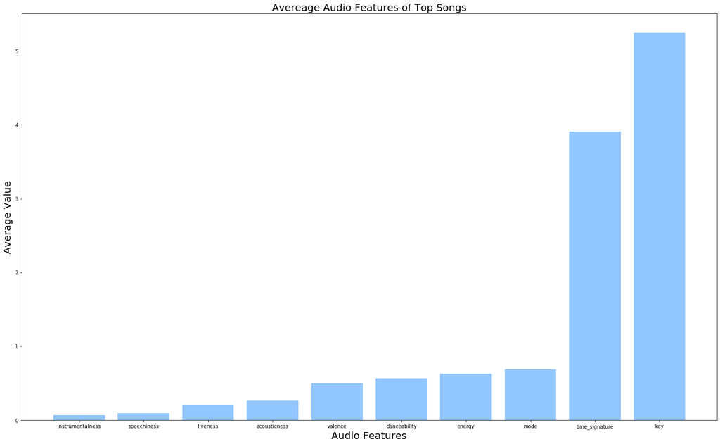

```python
#plot audio features for high-ranked songs
plt.figure(figsize=(25,15))
plt.title("Avereage Audio Features of Top Songs", fontsize=20)
plt.xlabel("Audio Features", fontsize=20)
plt.ylabel("Average Value", fontsize=20)
plt.bar(top_song_avg.keys(),top_song_avg)
plt.show()
```

## 2.2 Popular Songs vs. Low Ranked Songs

In order to compare the audio features of low-ranked songs to high-ranked songs, let's first look at the lowest rank in our table. We can do this by getting the value counts of the data in the 'rank' column.

```python
#get counts of ranks
acoustic_features['rank'].value_counts().sort_index()
```

```
1.0      933
2.0      531
3.0      493
4.0      452
5.0      383
        ...
196.0     59
197.0     56
198.0     61
199.0     45
200.0     54
Name: rank, Length: 200, dtype: int64
```

```python
#isolate low ranked songs
low_ranked = acoustic_features[acoustic_features['rank'] == 200]
low_ranked.head()
```

|  | album | artist | date | acousticness | danceability | duration_ms | energy | instrumentalness | key | liveness | loudness | mode | speechiness | tempo | time_signature | valence | rank |
| --- | --- | --- | --- | --- | --- | --- | --- | --- | --- | --- | --- | --- | --- | --- | --- | --- | --- |
| 767 | Absent Sounds | From Indian Lakes | 2014-10-07 | 0.227242 | 0.549900 | 209011.400000 | 0.612700 | 0.030051 | 3.900000 | 0.143480 | -10.284600 | 0.800000 | 0.032190 | 134.453900 | 3.600000 | 0.462800 | 200.0 |
| 1082 | All My Friends (EP) | Snakehips | 2015-10-21 | 0.119000 | 0.689000 | 229747.000000 | 0.521000 | 0.000084 | 0.000000 | 0.108000 | -5.845000 | 1.000000 | 0.132000 | 95.055000 | 4.000000 | 0.178000 | 200.0 |
| 1181 | Almas Gemelas | El Trono de Mexico | 2008-01-01 | 0.269833 | 0.718167 | 191816.666667 | 0.636167 | 0.000102 | 7.250000 | 0.220558 | -4.060833 | 0.750000 | 0.034558 | 129.954667 | 4.000000 | 0.917583 | 200.0 |
| 1644 | Arm's Way | Islands | 2008-05-20 | 0.013364 | 0.423667 | 340382.166667 | 0.744583 | 0.044316 | 5.000000 | 0.146642 | -6.349917 | 0.583333 | 0.057133 | 120.230833 | 3.916667 | 0.384083 | 200.0 |
| 1837 | Awaken The Fire | Like A Storm | 2015-02-24 | 0.047978 | 0.411455 | 257383.636364 | 0.854727 | 0.028590 | 6.727273 | 0.178491 | -4.913091 | 0.727273 | 0.086245 | 132.857818 | 3.909091 | 0.271727 | 200.0 |

```python
#get audio features for low ranked songs
low_ranked_avg = low_ranked.loc[:,'acousticness':'valence'].mean()
low_ranked_avg = low_ranked_avg.sort_values()
low_ranked_avg
```

```
loudness                -8.812162
speechiness              0.072896
instrumentalness         0.114487
liveness                 0.207181
acousticness             0.295363
valence                  0.492787
danceability             0.529326
energy                   0.619809
mode                     0.715407
time_signature           3.895602
key                      5.505765
tempo                  119.735982
duration_ms         257296.424577
dtype: float64
```

Again dropping very low and very high values...

```python
low_ranked_avg = low_ranked_avg.drop(labels=['duration_ms', 'tempo', 'loudness'])
```

Since we have the average data for the lowest and highest ranked songs we can graph them side-by-side and see if the value differ

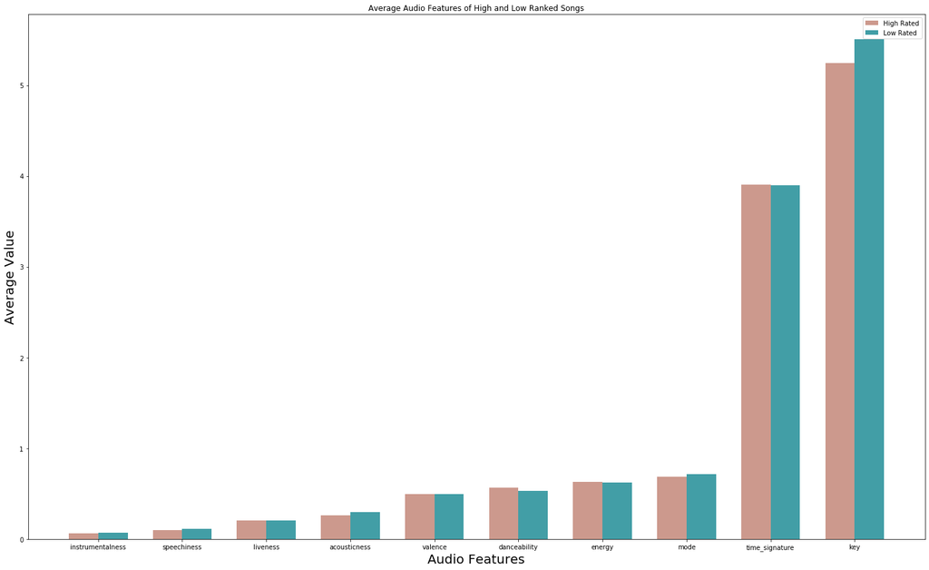

```python
#create side-by-side bar graph for low vs high ranked songs
ind = np.arange(len(low_ranked_avg))
#set distance between bars
width = 0.35

fig = plt.figure(figsize=(25,15))
ax = fig.add_subplot(111)
avgs1 = ax.bar(ind, top_song_avg, width, color='#CC998D')
avgs2 = ax.bar(ind+width, low_ranked_avg, width, color='#429EA6')

ax.set_ylabel('Average Value', fontsize=20)
ax.set_xlabel('Audio Features', fontsize=20)
ax.set_title('Average Audio Features of High and Low Ranked Songs')
ax.set_xticks(ind + width / 2)
ax.set_xticklabels(top_song_avg.keys())
ax.legend( (avgs1[0], avgs2[0]), ('High Rated', 'Low Rated') )
plt.show()
```

**Observations**

A bar graph of the difference in each feature will better demonstrate the change in average feature value between low and high rated songs.

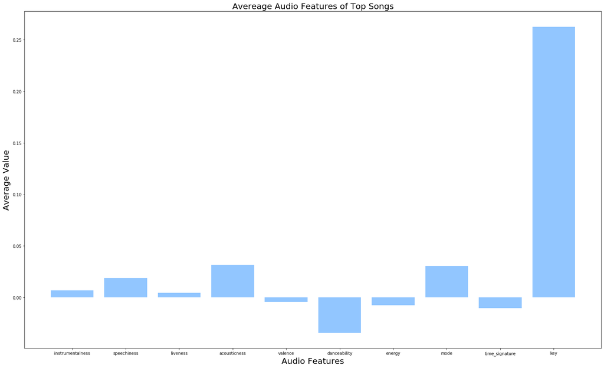

```python
#get difference between values for high and low ranked songs
diffs = [a - b for a, b in zip(low_ranked_avg, top_song_avg)]

#plot
plt.figure(figsize=(25,15))
plt.title("Avereage Audio Features of Top Songs", fontsize=20)
plt.xlabel("Audio Features", fontsize=20)
plt.ylabel("Average Value", fontsize=20)
plt.bar(top_song_avg.keys(),diffs)
plt.show()
```

**Observations**

- The highest difference between averages is for 'key'
- The second highest difference is for 'dancibility'
- All other differences seem to be less than or around 0.25

This may indicate that key and dancibility are highly influenctial in determining a song's rank. To evaluate this, we will determine the correlation of these factors in our analysis section.

# 3. Exploring Middle Ground

## 3.1 Slicing Ranks

Since there was the greatest difference in the average value for the 'key' of top-ranked songs and low-ranked songs, we decided to look at what the value of 'key' was for other levels of rank. We did this by creating a violin-plot where we demonstrate the distribution of 'key' value for each level of rank. Since ranks can be 1-200, we will begin by slicing the ranks into groups of 10 (<= 10, <=20, etc.)

```python
#convert rank column to int for binning
acoustic_features['rank'] = acoustic_features['rank'].astype(int)
#bin rank values
acoustic_features['rank_bins'] = pd.cut(acoustic_features['rank'], np.arange(0,201,10))
acoustic_features.loc[0:5,'rank':'rank_bins']
```

|  | rank | rank_bins |
| --- | --- | --- |
| 0 | 1 | (0, 10] |
| 1 | 158 | (150, 160] |
| 2 | 80 | (70, 80] |
| 3 | 180 | (170, 180] |
| 4 | 5 | (0, 10] |
| 5 | 88 | (80, 90] |

## 3.2 Measuring Distrubution of 'Key' per Rank

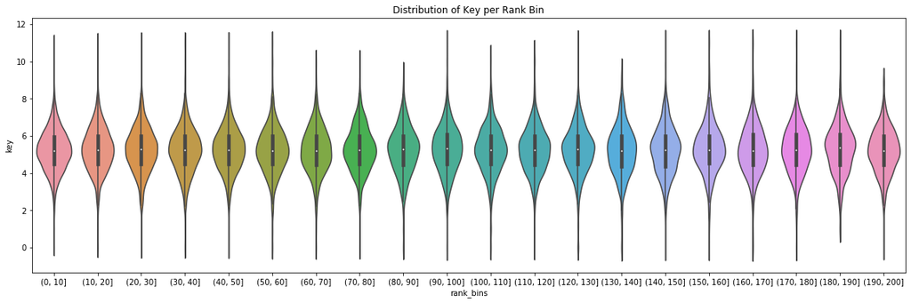

```python
#plot distributions for key value
plt.figure(figsize=(20, 6))
plt.title("Distribution of Key per Rank Bin")
ax = sns.violinplot(x=acoustic_features["rank_bins"], y=acoustic_features['key'])
```

## 3.3 Measuring Distribution of 'Danceability' per Rank

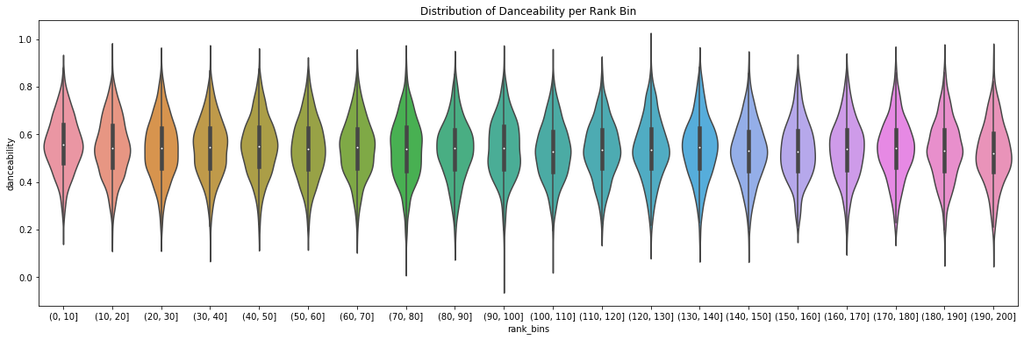

```python
#plot distributions for danceability level
plt.figure(figsize=(20, 6))
plt.title("Distribution of Danceability per Rank Bin")
ax = sns.violinplot(x=acoustic_features["rank_bins"], y=acoustic_features['danceability'])
```

**Observations**

- Most distributions are symmetrical
- Even though danceability levels differ by rank, the levels tend to be similar for inviduals ranks
- Danceability levels for high ranks seems to be slightly higher than very low ranks

# 4. Audio Features vs. Rank Analysis

## 4.1 Audio Features vs. Rank

We will now do a formal analysis of the correlation between audio features and rank. To begin, let's make a correlation dataframe using the all the audio features and the rank column in ACOUSTIC_FEATURES.

```python
#creates list of audio features
variables = list(acoustic_features.columns[3:-2])
'''
add rank to list because we want to measure
it's correlation to the audio features
'''
variables.insert(0,'rank')

#create correlation dataframe
corr_df = acoustic_features[variables]
corr_df = corr_df.corr()
corr_df = corr_df.round(3)
corr_df
```

|  | rank | acousticness | danceability | duration_ms | energy | instrumentalness | key | liveness | loudness | mode | speechiness | tempo | time_signature | valence |
| --- | --- | --- | --- | --- | --- | --- | --- | --- | --- | --- | --- | --- | --- | --- |
| rank | 1.000 | 0.071 | -0.063 | 0.008 | -0.048 | 0.135 | 0.003 | 0.015 | -0.103 | 0.039 | -0.043 | -0.001 | -0.045 | 0.028 |
| acousticness | 0.071 | 1.000 | -0.157 | -0.051 | -0.771 | 0.114 | -0.071 | 0.006 | -0.565 | 0.181 | -0.027 | -0.332 | -0.351 | -0.143 |
| danceability | -0.063 | -0.157 | 1.000 | -0.085 | -0.002 | -0.221 | 0.064 | -0.211 | 0.053 | -0.141 | 0.248 | -0.140 | 0.278 | 0.606 |
| duration_ms | 0.008 | -0.051 | -0.085 | 1.000 | 0.027 | 0.147 | 0.019 | 0.121 | -0.089 | -0.107 | 0.015 | -0.028 | 0.024 | -0.127 |
| energy | -0.048 | -0.771 | -0.002 | 0.027 | 1.000 | -0.120 | 0.063 | 0.194 | 0.790 | -0.153 | 0.149 | 0.377 | 0.294 | 0.135 |
| instrumentalness | 0.135 | 0.114 | -0.221 | 0.147 | -0.120 | 1.000 | -0.021 | -0.042 | -0.284 | -0.099 | -0.131 | -0.031 | -0.088 | -0.181 |
| key | 0.003 | -0.071 | 0.064 | 0.019 | 0.063 | -0.021 | 1.000 | -0.002 | 0.037 | -0.162 | 0.072 | -0.010 | 0.038 | 0.050 |
| liveness | 0.015 | 0.006 | -0.211 | 0.121 | 0.194 | -0.042 | -0.002 | 1.000 | 0.040 | 0.018 | 0.333 | -0.014 | -0.057 | -0.092 |
| loudness | -0.103 | -0.565 | 0.053 | -0.089 | 0.790 | -0.284 | 0.037 | 0.040 | 1.000 | -0.074 | 0.066 | 0.288 | 0.231 | 0.006 |
| mode | 0.039 | 0.181 | -0.141 | -0.107 | -0.153 | -0.099 | -0.162 | 0.018 | -0.074 | 1.000 | -0.206 | 0.062 | -0.063 | 0.050 |
| speechiness | -0.043 | -0.027 | 0.248 | 0.015 | 0.149 | -0.131 | 0.072 | 0.333 | 0.066 | -0.206 | 1.000 | -0.187 | -0.043 | -0.000 |
| tempo | -0.001 | -0.332 | -0.140 | -0.028 | 0.377 | -0.031 | -0.010 | -0.014 | 0.288 | 0.062 | -0.187 | 1.000 | 0.141 | 0.069 |
| time_signature | -0.045 | -0.351 | 0.278 | 0.024 | 0.294 | -0.088 | 0.038 | -0.057 | 0.231 | -0.063 | -0.043 | 0.141 | 1.000 | 0.235 |
| valence | 0.028 | -0.143 | 0.606 | -0.127 | 0.135 | -0.181 | 0.050 | -0.092 | 0.006 | 0.050 | -0.000 | 0.069 | 0.235 | 1.000 |

We can use the correlation dataframe to create a heat map which will provide a visual representation of the correlation between each column in our dataframe.

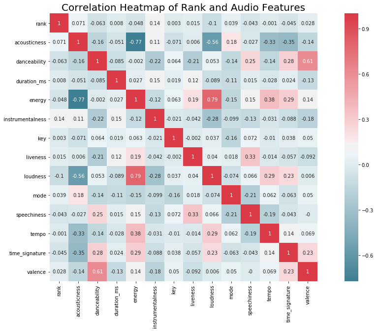

```python
plt.figure(figsize=(20,10))
plt.title("Correlation Heatmap of Rank and Audio Features", fontsize=20)
sns.heatmap(corr_df, cmap=sns.diverging_palette(220, 10, as_cmap=True), square=True, annot=True)
plt.show()
```

**Observations**

- Unfortunately, no audio feature is highly correlated to rank. The highest correlated audio feature to rank is instrumentalness (this represents the amount of vocals in a song).
- Danceability and key are very low correlated to rank
- Loudness and energy are highly correlated. This is not surprising as the two audio features are often associated.

## 4.2 Audio Features vs. Rank by Decade

```python
#convert date column from string to DateTime object
ft_date = acoustic_features.copy(deep=True)
ft_date['date'] = ft_date['date'].astype('datetime64[ns]')
#get min and max date
low = ft_date['date'].min()
high = ft_date['date'].max()
#create bins
bins_dt = pd.date_range(start='1899-01-01 00:00:00', end='2020-04-08 00:00:00', periods=10)
#create bins column
ft_date['date_bins'] = pd.cut(ft_date.date,bins=bins_dt)
ft_date.sample(n=3)
```

|  | album | artist | date | acousticness | danceability | duration_ms | energy | instrumentalness | key | liveness | loudness | mode | speechiness | tempo | time_signature | valence | rank | rank_bins | date_bins |
| --- | --- | --- | --- | --- | --- | --- | --- | --- | --- | --- | --- | --- | --- | --- | --- | --- | --- | --- | --- |
| 6333 | Facelift | Alice In Chains | 1990-01-01 | 0.014631 | 0.323750 | 269962.333333 | 0.793833 | 0.000068 | 6.416667 | 0.172558 | -9.131500 | 0.750000 | 0.058775 | 113.070500 | 4.0 | 0.354333 | 42 | (40, 50] | (1979-11-06, 1993-04-27 08:00:00] |
| 23523 | Witness Protection | Dave Hollister | 2008-08-01 | 0.394381 | 0.500312 | 278691.687500 | 0.572500 | 0.004046 | 7.125000 | 0.175881 | -7.330063 | 0.625000 | 0.095113 | 119.148750 | 4.0 | 0.460875 | 88 | (80, 90] | (2006-10-17 16:00:00, 2020-04-08] |
| 8500 | High Adventure | Kenny Loggins | 1982-01-01 | 0.335344 | 0.562222 | 276874.111111 | 0.515111 | 0.000111 | 5.444444 | 0.154344 | -12.441444 | 0.777778 | 0.037289 | 108.136556 | 4.0 | 0.597000 | 13 | (10, 20] | (1979-11-06, 1993-04-27 08:00:00] |

Now that we've but our songs into bins, we can create the heatmaps for each time period!

```
Length of Dataset: 608
```

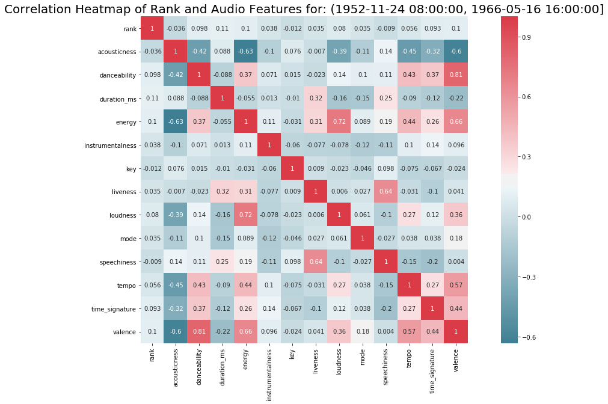

```
Length of Dataset: 5837
```

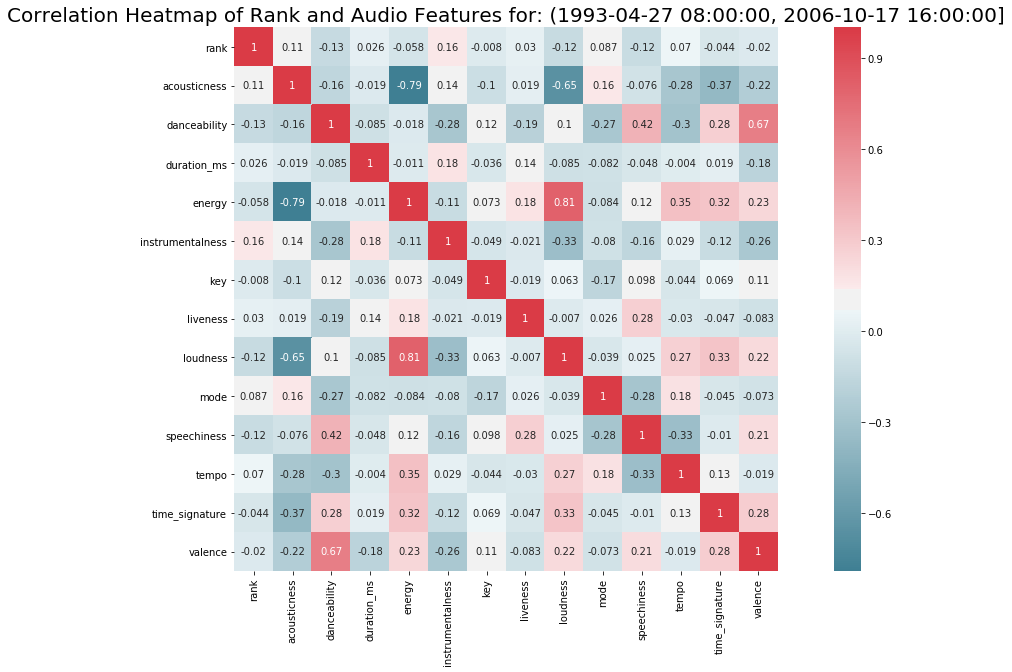

```
Length of Dataset: 10101
```

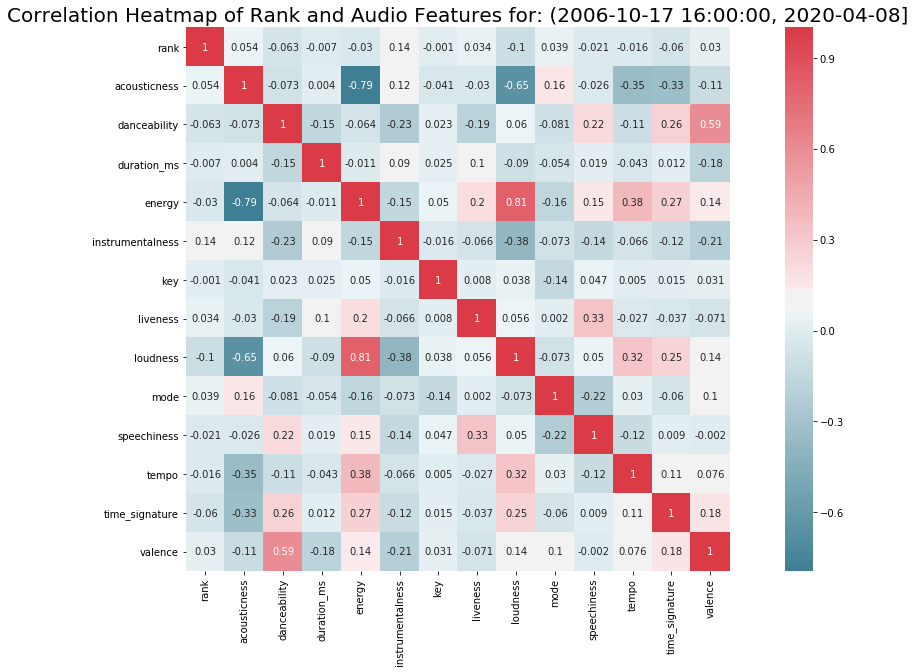

```
Length of Dataset: 3583
```

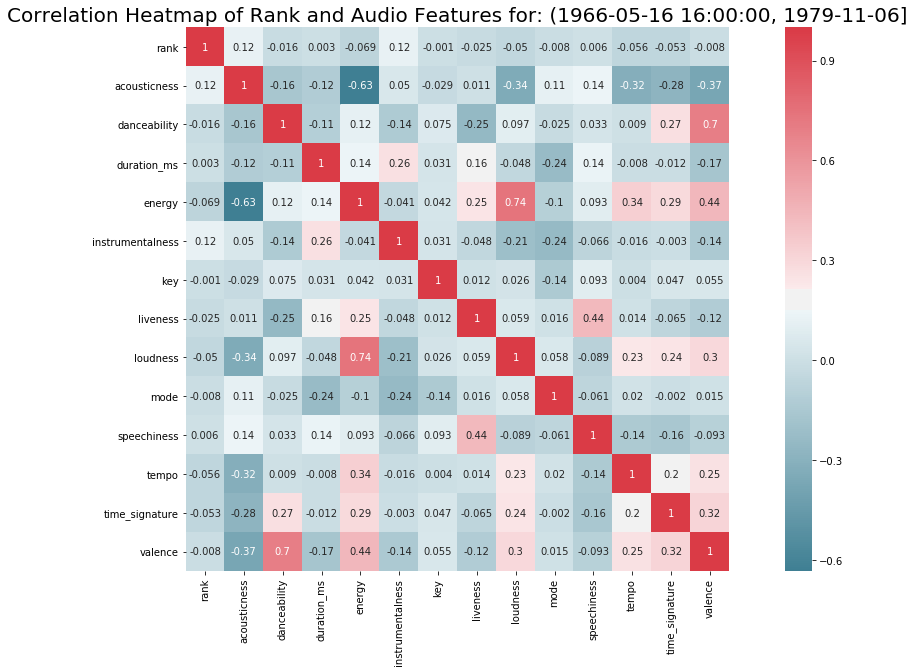

```
Length of Dataset: 3915
```

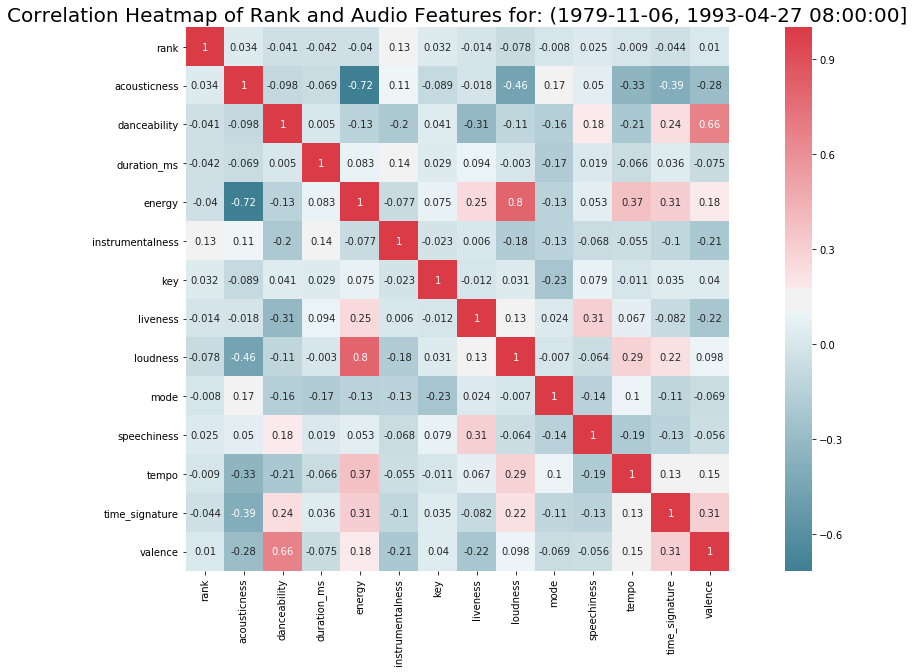

```
Length of Dataset: 5
```

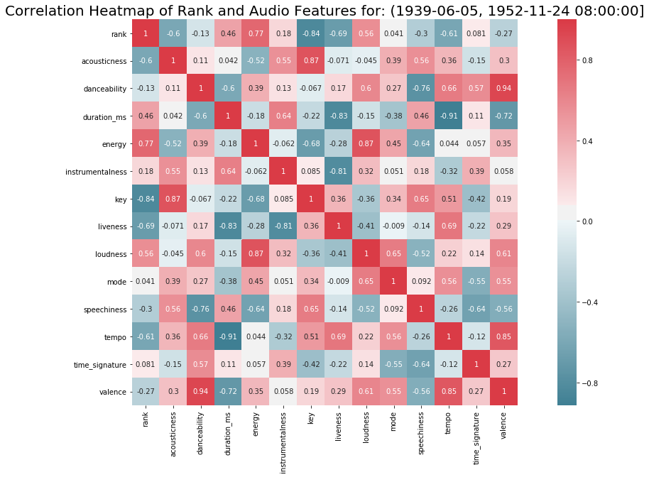

```python
for item in ft_date['date_bins'].unique():
    curr = ft_date[ft_date['date_bins'] == item]
    curr = curr[variables]
    if len(curr) > 1:
        print("Length of Dataset:", len(curr))
        curr = curr.corr()
        curr = curr.round(3)
        plt.figure(figsize=(20,10))
        plt.title(str("Correlation Heatmap of Rank and Audio Features for: " + str(item)), fontsize=20)
        sns.heatmap(curr, cmap=sns.diverging_palette(220, 10, as_cmap=True), square=True, annot=True)
        plt.show()
```

**Observations**

Correlations from rank to acoustic features remain weak until the time periods between 1939 and 1952. Upon further exploration, we found that this was because the datasets for these time periods were extremely small in comaprison to the datasets for later time periods. In order words, there is less variance in the data. Because we cannot rely on the heatmaps of earlier years to draw conclusions, we can conclude that splitting the data into time periods does not show a strong correlation between rank and acoustic features.

We also notice that acoustic feature values change over time. This is something we might want to use in our regression analysis in the next section, so we'll add another column for the year of the album, starting at 0.

```python
years = acoustic_features['date'].apply(lambda d: int(str(d)[:4]))
years
```

```
0        1965
1        1999
2        2007
3        2012
4        2016
         ...
24045    2009
24046    2018
24047    2007
24048    2001
24049    2002
Name: date, Length: 24050, dtype: int64
```

```python
years = acoustic_features['date'].apply(lambda d: int(str(d)[:4]))
first_year = years.min()
acoustic_features['norm_year'] = years.apply(lambda d: d - first_year)
acoustic_features
```

|  | album | artist | date | acousticness | danceability | duration_ms | energy | instrumentalness | key | liveness | loudness | mode | speechiness | tempo | time_signature | valence | rank | rank_bins | norm_year |
| --- | --- | --- | --- | --- | --- | --- | --- | --- | --- | --- | --- | --- | --- | --- | --- | --- | --- | --- | --- |
| 0 | !!Going Places!! | Herb Alpert & The Tijuana Brass | 1965-10-01 | 0.516250 | 0.649250 | 148865.416667 | 0.498167 | 0.671992 | 5.416667 | 0.110133 | -11.768333 | 0.583333 | 0.076958 | 116.482167 | 4.000000 | 0.686667 | 1 | (0, 10] | 65 |
| 1 | !Viva El Amor! | Pretenders | 1999-06-22 | 0.148281 | 0.499833 | 226313.416667 | 0.692000 | 0.002234 | 7.166667 | 0.165642 | -5.358083 | 0.750000 | 0.037475 | 126.393667 | 3.833333 | 0.538833 | 158 | (150, 160] | 99 |
| 2 | !Viva La Cobra! | Cobra Starship | 2007-10-22 | 0.043779 | 0.584727 | 201732.090909 | 0.785182 | 0.000010 | 2.636364 | 0.235309 | -5.923364 | 0.272727 | 0.074336 | 122.295636 | 3.727273 | 0.688545 | 80 | (70, 80] | 107 |
| 3 | "...Ya Know?" | Joey Ramone | 2012-05-22 | 0.119223 | 0.565800 | 208660.400000 | 0.778467 | 0.036745 | 6.800000 | 0.248173 | -5.157467 | 0.800000 | 0.040660 | 137.626267 | 3.933333 | 0.601000 | 180 | (170, 180] | 112 |
| 4 | "Awaken, My Love!" | Childish Gambino | 2016-12-02 | 0.302384 | 0.609727 | 267442.363636 | 0.473273 | 0.142471 | 3.181818 | 0.182145 | -10.846545 | 0.636364 | 0.118355 | 134.226636 | 3.727273 | 0.486664 | 5 | (0, 10] | 116 |
| ... | ... | ... | ... | ... | ... | ... | ... | ... | ... | ... | ... | ... | ... | ... | ... | ... | ... | ... | ... |
| 24045 | xx | The xx | 2009-08-18 | 0.662727 | 0.651727 | 210857.000000 | 0.370991 | 0.533082 | 7.363636 | 0.113218 | -13.458727 | 0.545455 | 0.046364 | 118.895727 | 4.090909 | 0.269691 | 92 | (90, 100] | 109 |
| 24046 | ye | Kanye West | 2018-06-01 | 0.306743 | 0.685857 | 203394.428571 | 0.503429 | 0.000000 | 5.000000 | 0.185957 | -5.668286 | 0.285714 | 0.314529 | 121.362714 | 4.000000 | 0.281386 | 1 | (0, 10] | 118 |
| 24047 | {Big Love In A Small Town} | Sarah Johns | 2007-08-28 | 0.249100 | 0.461182 | 204741.818182 | 0.758091 | 0.000087 | 4.727273 | 0.172918 | -3.155364 | 1.000000 | 0.040018 | 134.298000 | 3.909091 | 0.543636 | 198 | (190, 200] | 107 |
| 24048 | {Rotten Apples} Greatest Hits | The Smashing Pumpkins | 2001-01-01 | 0.055379 | 0.435000 | 247171.777778 | 0.713389 | 0.669189 | 6.500000 | 0.139256 | -7.458556 | 0.722222 | 0.046039 | 127.903722 | 3.888889 | 0.449167 | 31 | (30, 40] | 101 |
| 24049 | {Sensual Journey} | Will Downing | 2002-01-01 | 0.412164 | 0.633091 | 271882.272727 | 0.595818 | 0.001450 | 5.727273 | 0.139618 | -7.563636 | 0.636364 | 0.058218 | 109.561364 | 4.000000 | 0.443727 | 90 | (80, 90] | 102 |

24050 rows × 19 columns

# 5. Linear Regression

## 5.1 Null Hypothesis

Our null hypothesis states that none of the acoustic features will influence rank.

In the next step, we will verify the null hypothesis.

## 5.2. Regression with OLS

Regression will allow us to determine the strength of the relationship between the rank (our dependent variable) and the audio features (our independent variable).

To begin our regression we will create two separate dataframe for our independent and dependent variables. Our independent variables will reside in the features dataframe and our dependent variables will reside in the target dataframe.

We're using OLS because we can specify a relationship between two values easily by creating an `R`-like formula.

We'll create relationships between variables that had a correlation coefficient with high magnitude, and keep the others as they are, independent. We're defining a "high magnitude" as those values > 0.5 or < -0.5.

```python
formula = "rank ~ acousticness * energy + \
                  acousticness * loudness + \
                  danceability * valence + \
                  energy * loudness + \
                  duration_ms + \
                  instrumentalness + \
                  key + \
                  liveness + \
                  mode + \
                  speechiness + \
                  tempo + \
                  time_signature + \
                  norm_year"
```

The `*` characters indicate that we include both of the arguments as well as another coefficient for the relationship between them.

```python
train_data = acoustic_features.sample(frac=0.9, random_state=481)
test_data = acoustic_features.drop(train_data.index)
```

```python
regres = ols(formula, data=train_data).fit()
regres.summary()
```

OLS Regression Results

| Dep. Variable: | rank | R-squared: | 0.037 |
| --- | --- | --- | --- |
| Model: | OLS | Adj. R-squared: | 0.037 |
| Method: | Least Squares | F-statistic: | 46.77 |
| Date: | Mon, 16 Dec 2019 | Prob (F-statistic): | 8.76e-164 |
| Time: | 15:12:46 | Log-Likelihood: | -1.1876e+05 |
| No. Observations: | 21645 | AIC: | 2.376e+05 |
| Df Residuals: | 21626 | BIC: | 2.377e+05 |
| Df Model: | 18 |  |  |
| Covariance Type: | nonrobust |  |  |

|  | coef | std err | t | P>\|t\| | [0.025 | 0.975] |
| --- | --- | --- | --- | --- | --- | --- |
| Intercept | 12.4098 | 15.961 | 0.778 | 0.437 | -18.875 | 43.695 |
| acousticness | 87.0338 | 14.292 | 6.090 | 0.000 | 59.021 | 115.046 |
| energy | 46.5324 | 9.468 | 4.915 | 0.000 | 27.975 | 65.090 |
| acousticness:energy | -65.5233 | 14.583 | -4.493 | 0.000 | -94.108 | -36.939 |
| loudness | -2.6572 | 0.607 | -4.377 | 0.000 | -3.847 | -1.467 |
| acousticness:loudness | 3.3254 | 0.761 | 4.370 | 0.000 | 1.834 | 4.817 |
| danceability | -67.1493 | 10.413 | -6.449 | 0.000 | -87.559 | -46.740 |
| valence | -0.7830 | 10.750 | -0.073 | 0.942 | -21.854 | 20.288 |
| danceability:valence | 71.1353 | 18.262 | 3.895 | 0.000 | 35.339 | 106.931 |
| energy:loudness | -0.5133 | 0.762 | -0.674 | 0.500 | -2.007 | 0.980 |
| duration_ms | -3.286e-06 | 4.76e-06 | -0.691 | 0.490 | -1.26e-05 | 6.04e-06 |
| instrumentalness | 36.7524 | 2.534 | 14.502 | 0.000 | 31.785 | 41.720 |
| key | 0.4538 | 0.329 | 1.381 | 0.167 | -0.190 | 1.098 |
| liveness | 4.7692 | 3.407 | 1.400 | 0.162 | -1.908 | 11.446 |
| mode | 10.3831 | 2.145 | 4.841 | 0.000 | 6.179 | 14.587 |
| speechiness | -4.2091 | 5.264 | -0.800 | 0.424 | -14.528 | 6.109 |
| tempo | 0.0067 | 0.036 | 0.185 | 0.853 | -0.064 | 0.078 |
| time_signature | -4.0875 | 2.682 | -1.524 | 0.127 | -9.344 | 1.169 |
| norm_year | 0.1729 | 0.033 | 5.293 | 0.000 | 0.109 | 0.237 |

| Omnibus: | 3531.670 | Durbin-Watson: | 2.023 |
| --- | --- | --- | --- |
| Prob(Omnibus): | 0.000 | Jarque-Bera (JB): | 1796.488 |
| Skew: | 0.556 | Prob(JB): | 0.00 |
| Kurtosis: | 2.131 | Cond. No. | 1.65e+07 |

Warnings:  
[1] Standard Errors assume that the covariance matrix of the errors is correctly specified.  
[2] The condition number is large, 1.65e+07. This might indicate that there are  
strong multicollinearity or other numerical problems.

# 6. Prediction of Rank

We'll use the regression to predict rank values now. The `RegressionResults.predict()` method returns a Series of ranks with the associated indices, so we'll combine them in another DataFrame and then use that DF to create a scatter-plot with our predictions on the x-axis and actual rankings on the y-axis. We predicted that acoustic features were not a good indication of rank, so we should expect a graph with points not lined up.

If the prediction was correct, we should expect a diagonal line going from the bottom-left to the top-right.

```python
prediction = regres.predict(test_data)
```

```python
prediction
```

```
0        93.919838
4        70.204736
18       41.689679
20       59.989877
31       84.061026
           ...
24007    55.576583
24017    59.728076
24034    78.945507
24041    62.217092
24043    66.025679
Length: 2405, dtype: float64
```

```python
row = acoustic_features.iloc[23992]
row['rank']
```

```
40
```

```python
graph_df = pd.DataFrame(columns=['album', 'prediction', 'actual'])
for index, value in prediction.iteritems():
    row = acoustic_features.iloc[index]
    graph_df = graph_df.append({'album': row['album'],
                                'prediction': value,
                                'actual': row['rank']}, ignore_index=True)
graph_df.head()
```

|  | album | prediction | actual |
| --- | --- | --- | --- |
| 0 | !!Going Places!! | 93.919838 | 1 |
| 1 | "Awaken, My Love!" | 70.204736 | 5 |
| 2 | #SANTANAWORLD (+) | 41.689679 | 128 |
| 3 | #officialMBmusic | 59.989877 | 79 |
| 4 | 'Nuff Said | 84.061026 | 108 |

```python
plt.style.use('seaborn-poster')
```

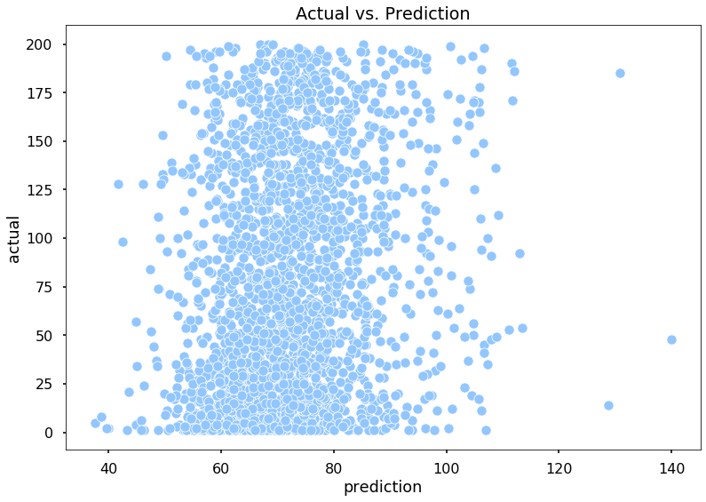

```python
sns.scatterplot(x='prediction', y='actual', data=graph_df)
plt.title('Actual vs. Prediction')
```

**Observations**:

As we predicted above, this graph looks messy and indicates poor performance in predicting ranking based on acoustic features alone.

# 7. Conclusions

## 7.1 Key Takeaways

Our regression showed us that acoustic features alone are not a good indication of whether an album will be popular, i.e. if it will reach the top of the Billboard 200. We were already observing that the acoustic features did not correspond strongly to the rank of the song. To make up for this, we added variables in the regression to create relationships between strongly-correlated features. This did not help in the regression, as we got a `R`-squared coefficient of 0.037.

Since we know that acoustic features alone are not a good indicator of performance on the Billboard 200, this begs the question: what are the factors? Or even, how many factors are there? Some further questions that could be explored are:

- Has the artist created several successful albums before?
- How similar are a popular artists' albums' acoustic features?
- How does the political climate affect the popularity of albums?
- How did news events surrounding artists contribute to their Billboard performance?
- How does the tone/message of the song affect its popularity? (This would be an interesting NLP component to add on).

## Further Reading

1. https://sites.psu.edu/siowfa15/2015/12/03/what-makes-a-song-a-hit/
2. https://towardsdatascience.com/data-science-for-hit-song-prediction-32370f0759c1
3. https://www8.gsb.columbia.edu/articles/projects/what-makes-a-hit/